# TP : Simulations et méthode de Monte-Carlo

UE STA103

Benjamin Hivert

Février 2022

# 1 Simulations de variables aléatoires

## 1.1 Illustrations graphiques

### 1.1.1 Histogramme et fonction de densité

1. Générer, à l’aide de la fonction `rnorm()`, $n=1000$ réalisations de variables aléatoires de loi normale $\mathcal{N}(2, 2)$.  
   [*Attention à la définition des paramètres, notamment variance/écart-type*]

```r
n <- 1000
realNorm <- rnorm(n, mean = 2, sd = sqrt(2))
```

2. Tracer l’histogramme des valeurs générées à l’aide de la fonction `hist()`.  
   [*Régler les paramètres de la fonction pour obtenir des proportions et non des effectifs*]

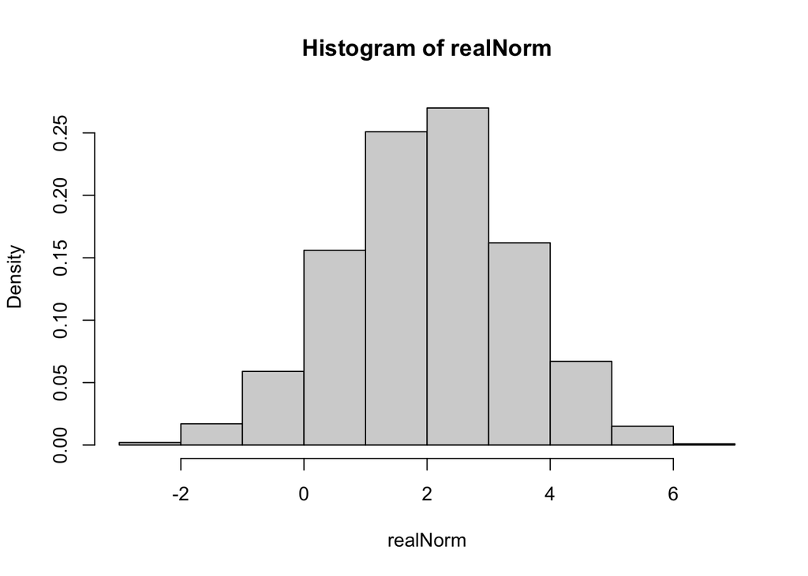

```r
hist(realNorm, probability = TRUE)
```

3. Ajouter, au graphique précédent et à l’aide de la fonction `curve()`, la courbe représentative en bleu de la fonction de densité de la loi $\mathcal{N}(2, 2)$, obtenue grâce à la fonction `dnorm()`.  
   [*La fonction `curve()` s’utilise en premier argument avec une expression dépendant de `x`, du genre “`nomFonction(x, param1 = valeur1, param2 = valeur2)`”*]

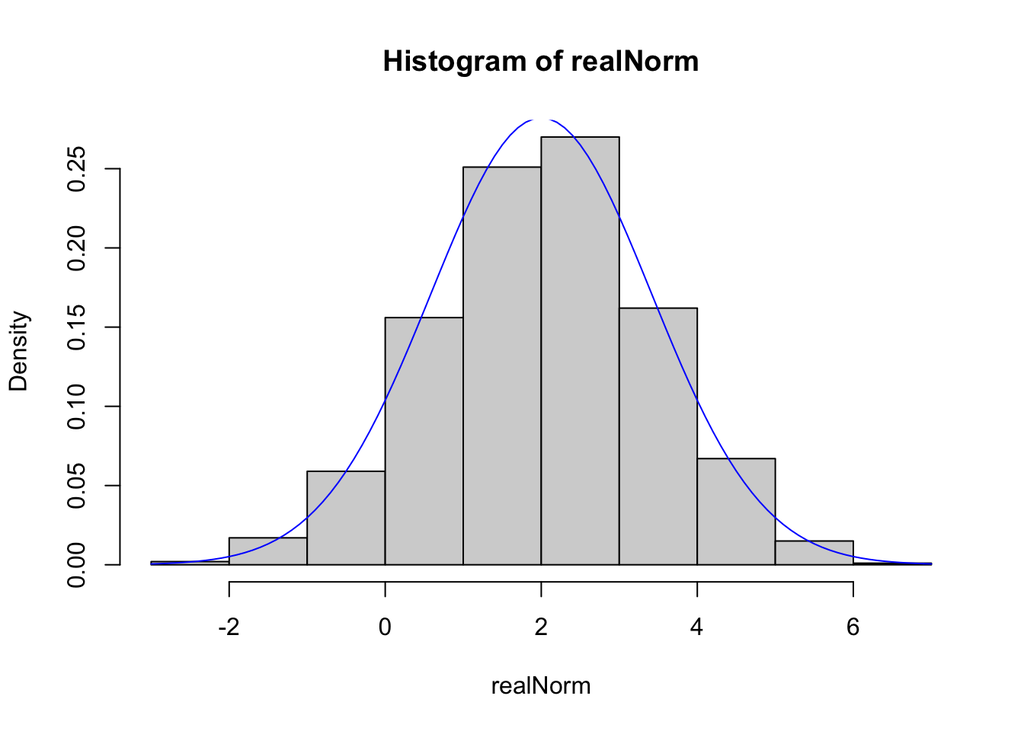

```r
hist(realNorm, probability = TRUE)
curve(dnorm(x, mean = 2, sd = sqrt(2)), add = TRUE, col = "blue")
```

### 1.1.2 Fonction de répartition, et fonction de répartition empirique

Un problème avec la représentation précédente, c’est que l’impression visuelle est parfois trompeuse car le nombre de barres doit être estimé au moment du tracé de l’histogramme.

Une autre manière de représenter l’adéquation entre une distribution empirique et une distribution théorique est d’utiliser les fonctions de répartitions.

**Rappel : Fonction de répartition et fonction de répartition empirique**

Soit $X$ une variable aléatoire, on définit sa fonction de répartition $F$ par $F(x) = \mathbb{P}(X\leq x)$.

Si $X$ est une variable aléatoire continue de densité $f$, alors on a : $F(x) = \int_{-\infty}^x f(t)dt$.

Étant donné un $n-$échantillon $(X_1, \dots, X_n)$ de même loi que $X$, on définit la fonction de distribution empirique $\hat{F}_n(x)$ par :
$$\hat{F}_n(x) = \frac{1}{n}\sum\limits_{i=1}^n \boldsymbol{1}_{X_i\leq x} = \frac{\text{nombre d'éléments inférieurs à }x \text{ dans l'échantillon}}{\text{taille de l'échantillon}}$$

Exécuter les commandes suivantes pour visualiser le fait que l’adéquation se fait de mieux en mieux lorsque $n$ grandit :

```r
nbObsVal <- c(50, 100, 500, 1000)
par(mfrow = c(2,2))
for (nbObs in nbObsVal) {
  realNorm <- rnorm(nbObs)
  ordNorm <- sort(realNorm)
  plot(ordNorm, (1:nbObs)/nbObs, type = "s", xlim = c(-3, 3),
       main = paste("n =", nbObs))
  curve(pnorm, add = TRUE, col = "blue")
}
```

[output not shown]

## 1.2 Méthode d’inversion

**Rappel : Méthode de la fonction d’inverse pour simuler des données selon une distribution** $P$ continue

Si la fonction de répartition $F$ associée à la distribution $P$ est inversible (*i.e* $F^{-1}$ existe) alors :

1. Simuler $U_1, \dots, U_n \sim \mathcal{U}([0,1])$
2. Calculer $X_1 = F^{-1}(U_1), \dots, X_n = F^{-1}(U_n)$
3. On a alors que $X_1,\dots, X_n$ est une échantillon de $P$
4. Générer un échantillon de taille $n=1000$ de loi $\mathrm{Exp}(2)$ à l’aide de la méthode d’inversion, puis vérifier votre résultat à l’aide d’un graphique. .  
   [*Utiliser le générateur `runif()`*]

**Application : Distribution exponentielle**

La fonction de répartition $F$ de la loi exponentielle $\mathrm{Exp}(\lambda)$ est donnée par $F(x) = 1 - \exp(-\lambda x)$. Ainsi, on a :

$$\begin{align*}
y &= 1- \exp(-\lambda x) \\
1-y &= \exp(-\lambda x) \\
\log(1-y) &= -\lambda x \\
-\frac{1}{\lambda} \log(1-y) &= x
\end{align*}$$

Donc $F^{-1}(x) = -\frac{1}{\lambda} \log(1-x)$

```r
u <- runif(n)
realExp <- - 1/2 * log(1-u)
```

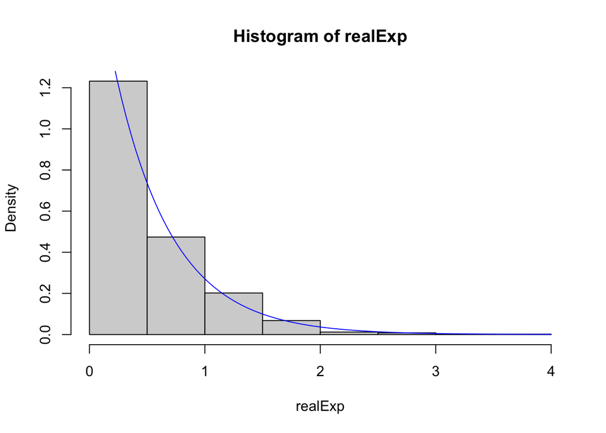

```r
hist(realExp, probability = TRUE)
curve(2*exp(-2*x), add = TRUE, col = "blue")
```

```r
# ou : curve(dexp(x, rate = 2), add = TRUE, col = "red")
```

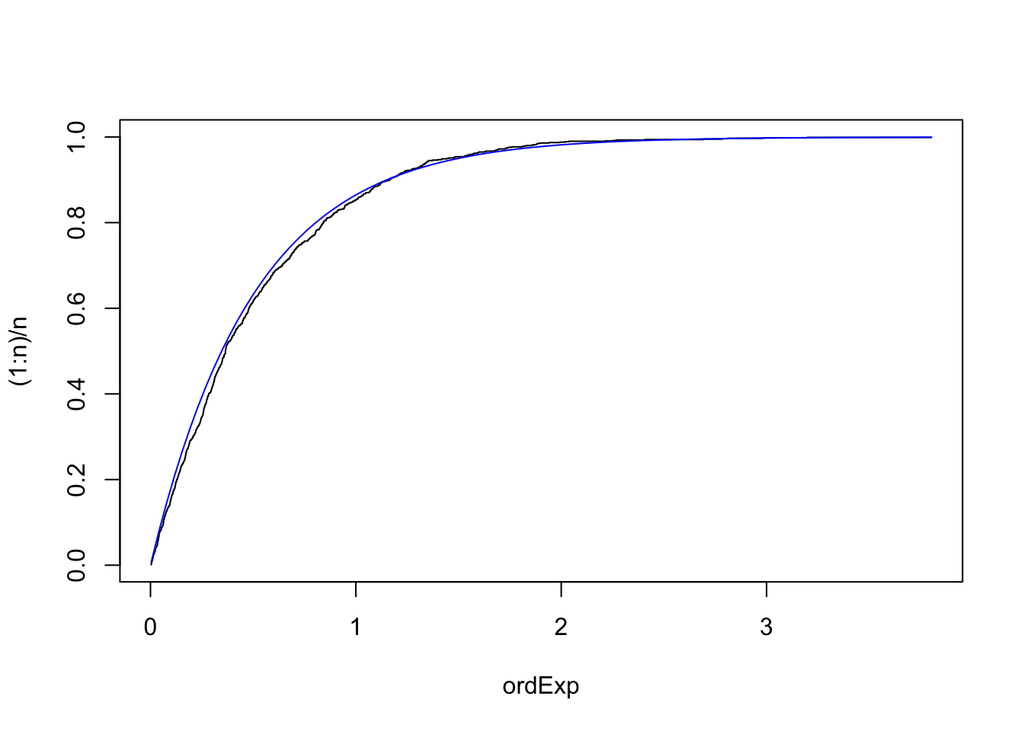

```r
ordExp <- sort(realExp)
plot(ordExp, (1:n)/n, type = "s")
curve(1-exp(-2*x), add = TRUE, col = "blue")
```

```r
# ou : curve(pexp(x, rate = 2), add = TRUE, col = "red")
```

5. Générer un échantillon de taille $n=1000$ de loi discrète défini sur $\{1, 2, 3, 4\}$ par les probabilités $(0.1, 0.3, 0.4, 0.2)$ à l’aide de la méthode d’inversion, puis vérifier votre résultat à l’aide d’un graphique.

**Rappel : Méthode de la fonction d’inverse pour simuler des données selon une distribution** $P_{\text{disc}}$ discrète

1. Simuler une variable aléatoire de loi $\mathcal{U}([0,1])$
2. Trouver la valeur de $k \geq 1$ telle que :
   $$\sum\limits_{j=1}^{k-1}p_j \leq U < \sum\limits_{j=1}^{k}p_j$$

```r
u <- runif(n)
probas <- c(0.1, 0.3, 0.4, 0.2)
realDisc <- cut(u, breaks = c(0, cumsum(probas)), labels = 1:4)
```

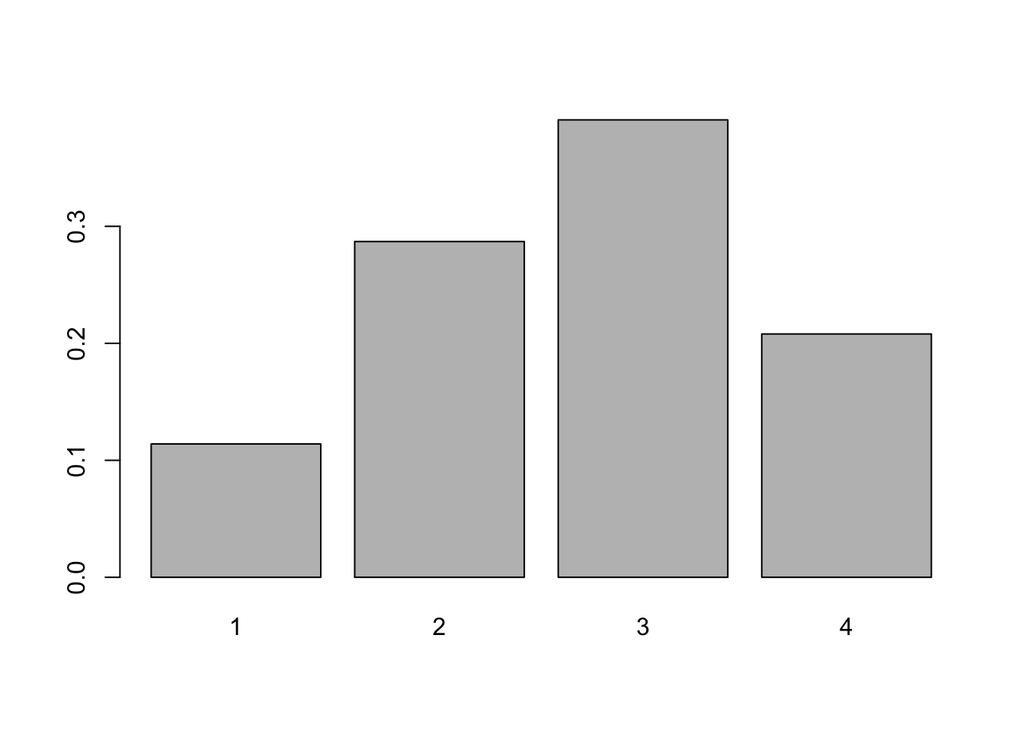

```r
barplot(prop.table(table(realDisc)))
```

## 1.3 Méthode de Box-Müller

6. Générer deux échantillons indépendants, $U_n$ et $V_n$ de réalisations de variables aléatoires $\mathcal{U}([0,1])$ de taille $n=1000$.

```r
u <- runif(n)
v <- runif(n)
```

7. Calculer pour chaque terme des échantillons $U_n$ et $V_n$ les éléments suivants : $X = \sqrt{-2 \ln(U)} \cos(2\pi V)$ et $Y = \sqrt{-2 \ln(U)} \sin (2\pi V)$.

```r
x <- sqrt(-2*log(u))*cos(2*pi*v)
y <- sqrt(-2*log(u))*sin(2*pi*v)
```

8. Déterminer la distribution des échantillons $X_n$ et $Y_n$ ainsi construits et calculer la corrélation entre ces échantillons.

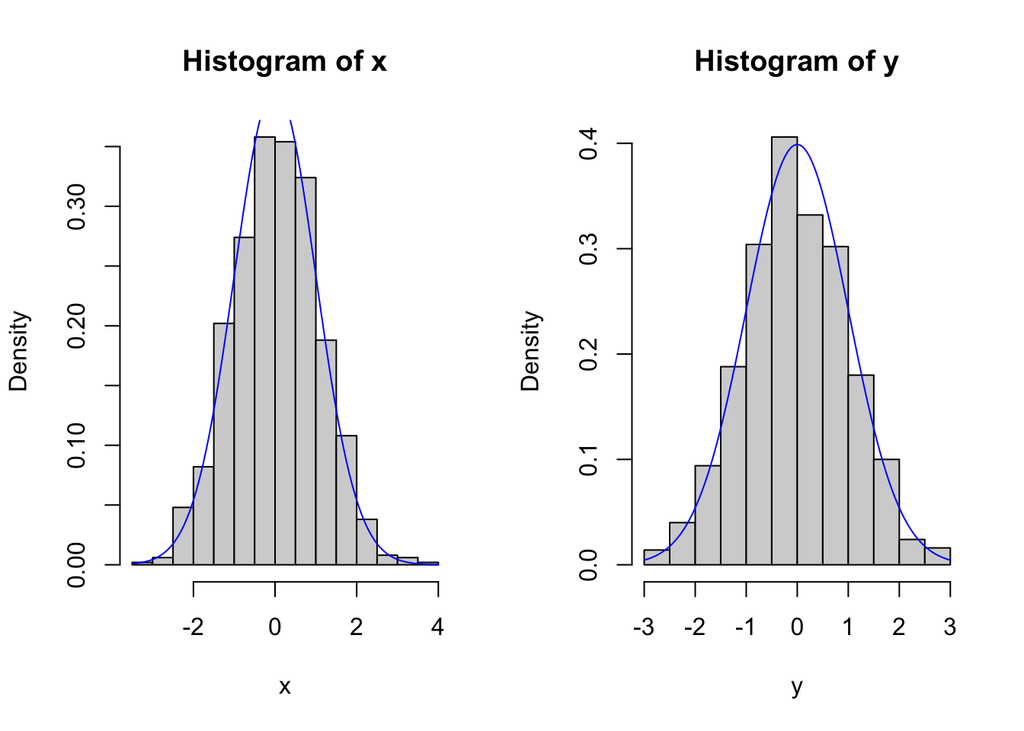

```r
par(mfrow=c(1,2))
hist(x, probability = TRUE)
curve(dnorm, add = TRUE, col = "blue")
hist(y, probability = TRUE)
curve(dnorm, add = TRUE, col = "blue")
```

```r
cor(x, y)
```

```
## [1] 0.01016419
```

**La corrélation doit être proche de zéro. En effet, cette construction est faite pour les variables $X$ et $Y$ construites soient indépendantes toutes deux de loi $\mathcal{N}(0,1)$. Attention, par contre ce n’est pas parce que la corrélation est nulle que les variables sont forcément indépendantes !**

**Méthode de Box-Müller**

La méthode de Box-Müller permet de simuler deux échantillons indépendants de distributions gaussiennes centrées-réduites à partir de réalisations de distributions uniformes.

# 2 Méthode de Monte-Carlo

**Rappel : Méthode de Monte-Carlo**

La méthode de Monte-Carlo permet d’approcher la valeur d’une intégrale $\mathcal{I}$. S’il est possible d’écrire l’intégrale $\mathcal{I}$ comme l’espérance d’une fonction de variables aléatoires de lois fixées, *i.e* si $\mathcal{I} = \mathbb{E}[g(X_1,\dots, X_p)]$, alors pour approcher $\mathcal{I}$ :

1. On simule $N$ réalisations des variables aléatoires. On note $x_1^l, \dots, x_p^l$ la réalisation numéro $l$.
2. On approche $\mathcal{I}$ par :
   $$\hat{\mathcal{I}} = \frac{1}{N} \sum\limits_{l=1}^N g(x_1^l, \dots, x_p^l)$$

## 2.1 Espérance et variance de la loi exponentielle

9. Générer $n=1000$ réalisations d’une variable aléatoire $X \sim \mathrm{Exp}(\frac{1}{2})$, puis donner une valeur approchée de l’espérance de $X$.

**Application : Distribution exponentielle**

On souhaite approcher $\mathbb{E}[X]$ pour $X\sim\mathrm{Exp}(1/2)$. Pour cela, il suffit de tirer $N$ réalisations $X_1, \dots, X_N$ d’une variable aléatoire $\mathrm{Exp}(1/2)$ et d’approcher $\mathbb{E}[X]$ par $\frac{1}{N} \sum \limits_{i=1}^N X_i$

**Rappel :** Si $X\sim\mathrm{Exp}(\lambda)$ alors $\mathbb{E}[X] = \frac{1}{\lambda}$

```r
realExp <- rexp(n, rate = 1/2)
mean(realExp)
```

```
## [1] 1.890741
```

10. Illustrer la convergence de l’estimateur.  
    [*Tracer l’évolution de l’estimation en fonction du nombre de variables aléatoires générées*]

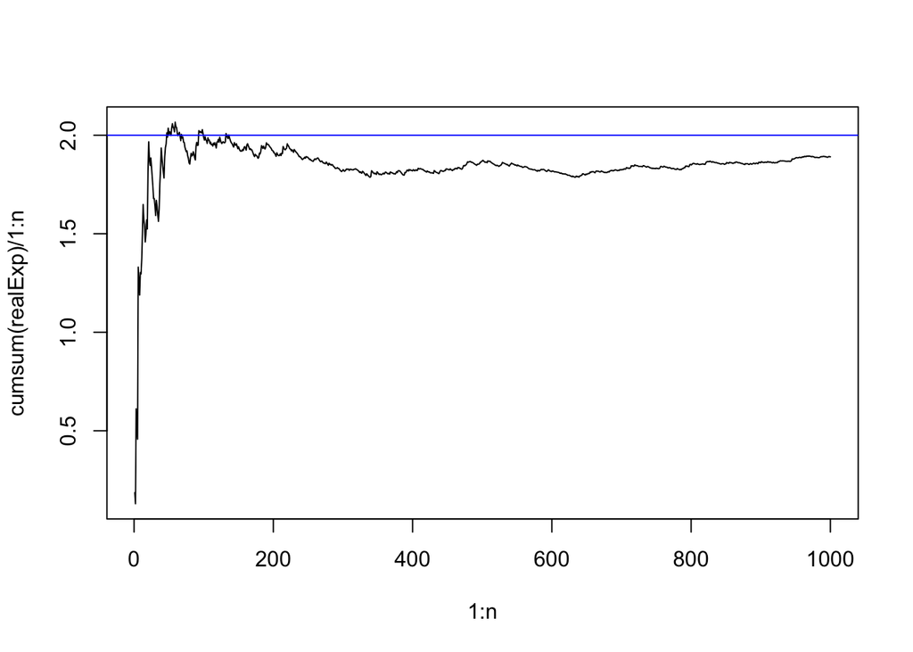

```r
plot(1:n, cumsum(realExp) / 1:n, type = "l")
abline(h = 2, col = "blue")
```

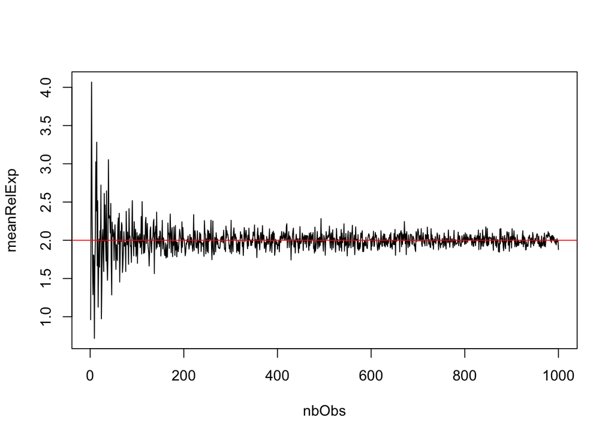

```r
## Autre méthodes
nbObs <- seq(1, 1000, 1)
meanRelExp <- rep(NA, length(nbObs))

for (i in 1:length(nbObs)){
  relExpMC <- rexp(nbObs[i], rate = 1/2)
  meanRelExp[i] <- mean(relExpMC)
}

plot(nbObs, meanRelExp, type = "l")
abline(h=2, col = "red")
```

11. Donner également une valeur approchée de la variance de $X$.

**Rappel : Définition de la variance**

La variance d’une variable aléatoire $X$ est définie par :
$$\begin{align*}
\operatorname{Var}(X) &= \mathbb{E}\left[(X-\mathbb{E}[X])^2\right] \\
&= \mathbb{E}[X^2]-\mathbb{E}[X]^2
\end{align*}$$

**Rappel :** Si $X\sim \mathrm{Exp}(\lambda)$ alors $\operatorname{Var}(X) = \frac{1}{\lambda^2}$

**Application : Distribution exponentielle**

Ici, on souhaite approcher $\operatorname{Var}(X)$ pour $X\sim\mathrm{Exp}(1/2)$. Il faut donc approcher :

1. $\mathbb{E}[X^2]$ : On peut ré-écrire cette espérance comme : $\mathbb{E}[g(X)]$ où $X \sim \mathrm{Exp}(1/2)$ et $g : x \mapsto x^2$. Donc par Monte-Carlo, cette espérance peut être approchée par :
   $$\frac{1}{N} \sum\limits_{i=1}^N X_i^2$$
2. $\mathbb{E}[X]^2$ : A la question précédente, on a déjà donné une estimation de $\mathbb{E}[X]$, il suffit de la passer au carré.

Au final, on peut approcher la variance de $X$ par :
$$\frac{1}{N}\sum\limits_{i=1}^N X_i^2 - \left(\frac{1}{N}\sum\limits_{i=1}^N X_i\right)^2$$

```r
mean(realExp^2) - mean(realExp)^2
```

```
## [1] 3.188965
```

```r
var(realExp)
```

```
## [1] 3.192157
```

**Rappel : Estimateur sans biais de la variance**

La fonction `var()` de R calcule l’estimateur sans biais de la variance, c’est pourquoi les deux résultats sont différents.

```r
var(realExp)*(n-1)/n
```

```
## [1] 3.188965
```

## 2.2 Approximation de l’aire d’une surface

L’aire d’une surface peut également être approchée par Monte-Carlo.

### 2.2.1 Aire du disque unité

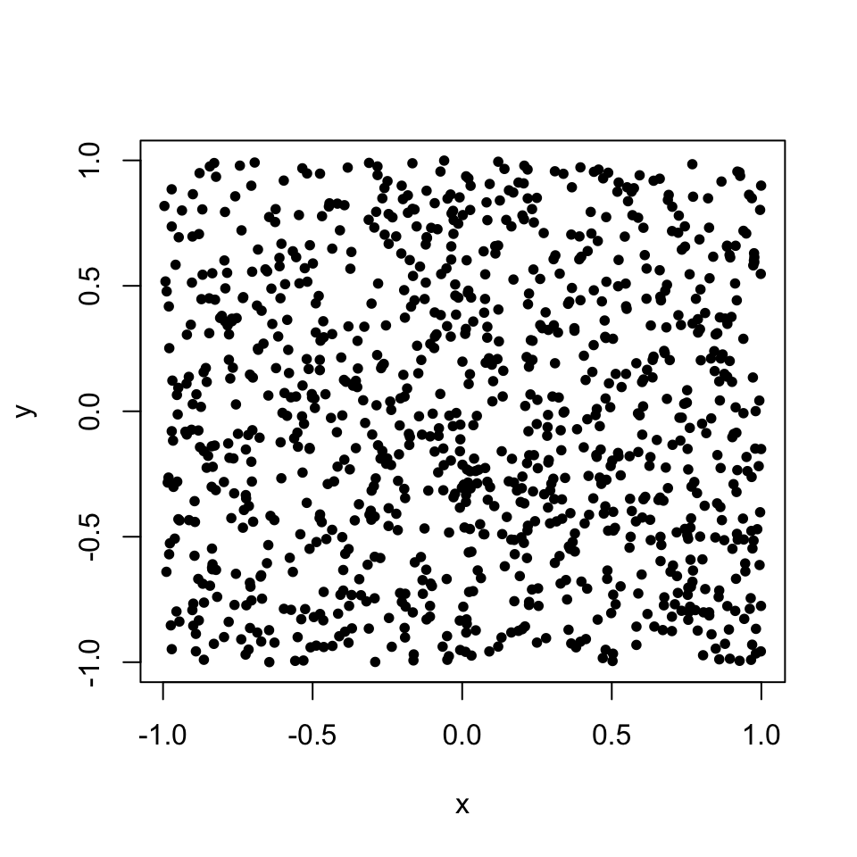

```r
unifCarre <- data.frame(x = runif(n, -1, 1), y = runif(n, -1, 1))
plot(unifCarre, pch = 20)
```

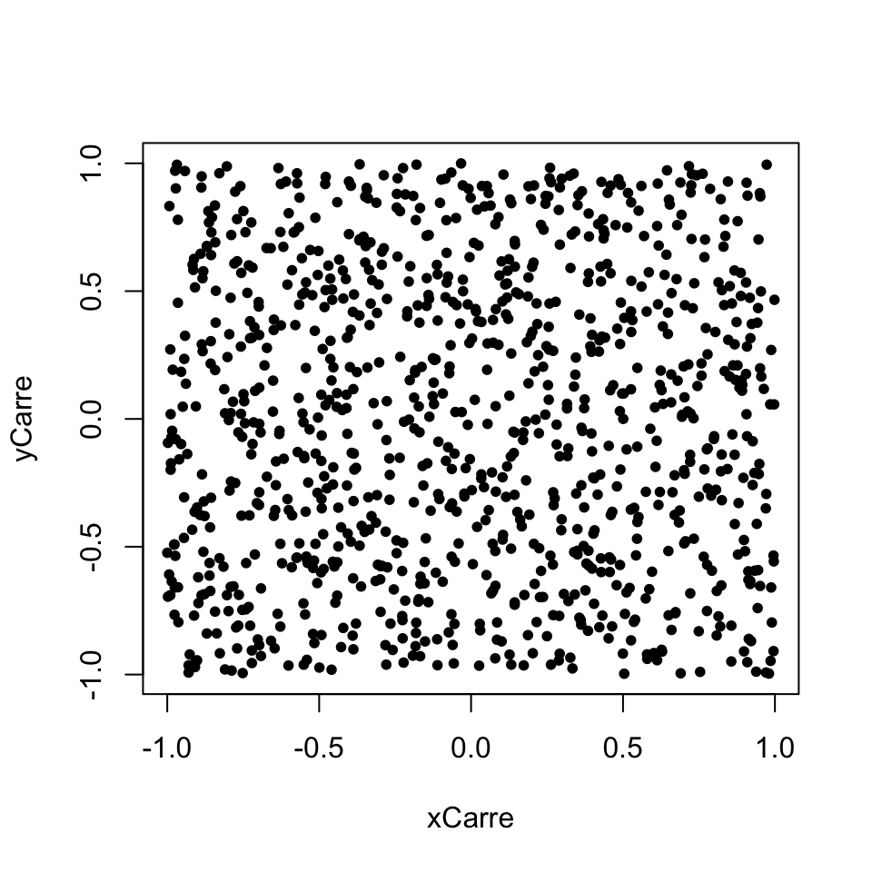

```r
#Ou
xCarre <- runif(n, -1, 1)
yCarre <- runif(n, -1, 1)

plot(xCarre, yCarre, pch = 20)
```

13. Déterminer quels points appartiennent au disque unité, défini par : $\{(x,y) : x^2 + y^2 \leq 1\}$. Faire apparaître ces points sur le graphique précédent.

```r
unifCarre <- transform(unifCarre, disque = (x^2 + y^2 <= 1))
#ou
unifCarre$disque2 <- (unifCarre$x^2+unifCarre$y^2)<=1

#ou
xyDisque <- (xCarre^2 + yCarre^2)<= 1
```

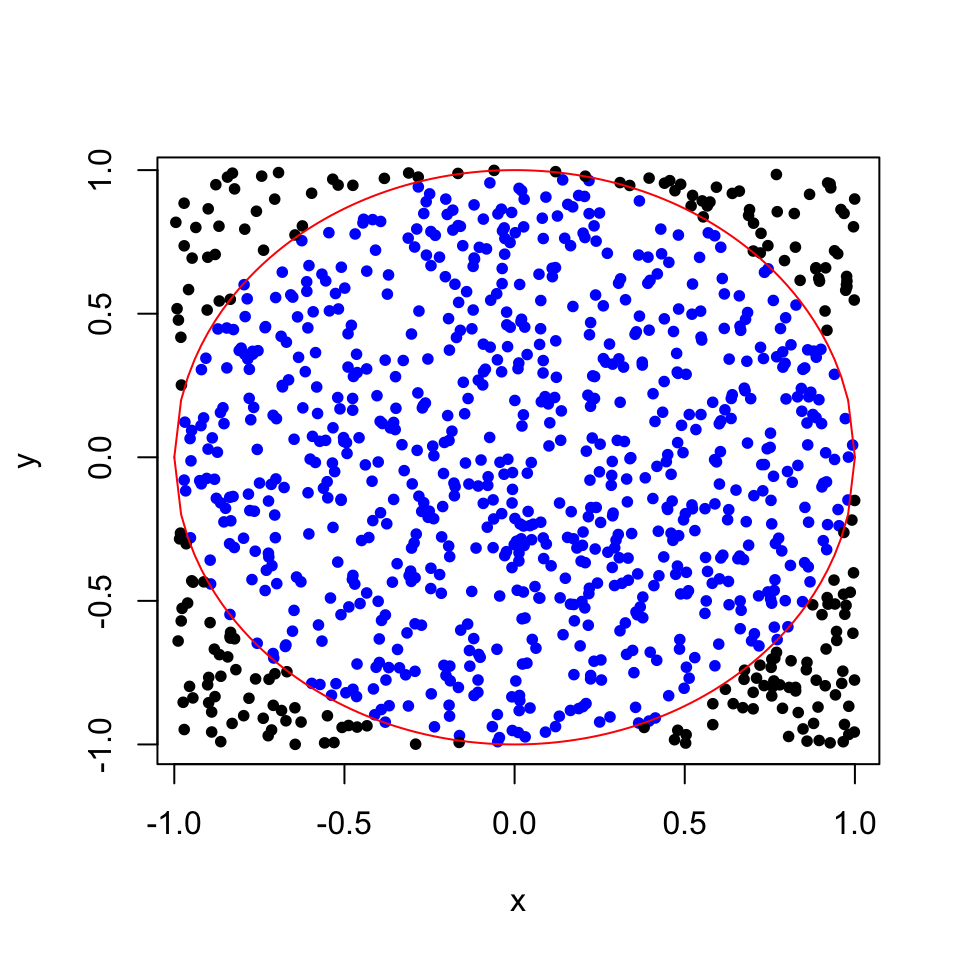

```r
plot(subset(unifCarre, disque, select = c("x", "y")), col = "blue", pch = 20)
points(subset(unifCarre, !disque, select = c("x", "y")), pch = 20)
curve(sqrt(1 - x^2), add = TRUE, from = -1, to = 1, col = "red")
curve(-sqrt(1 - x^2), add = TRUE, from = -1, to = 1, col = "red")
```

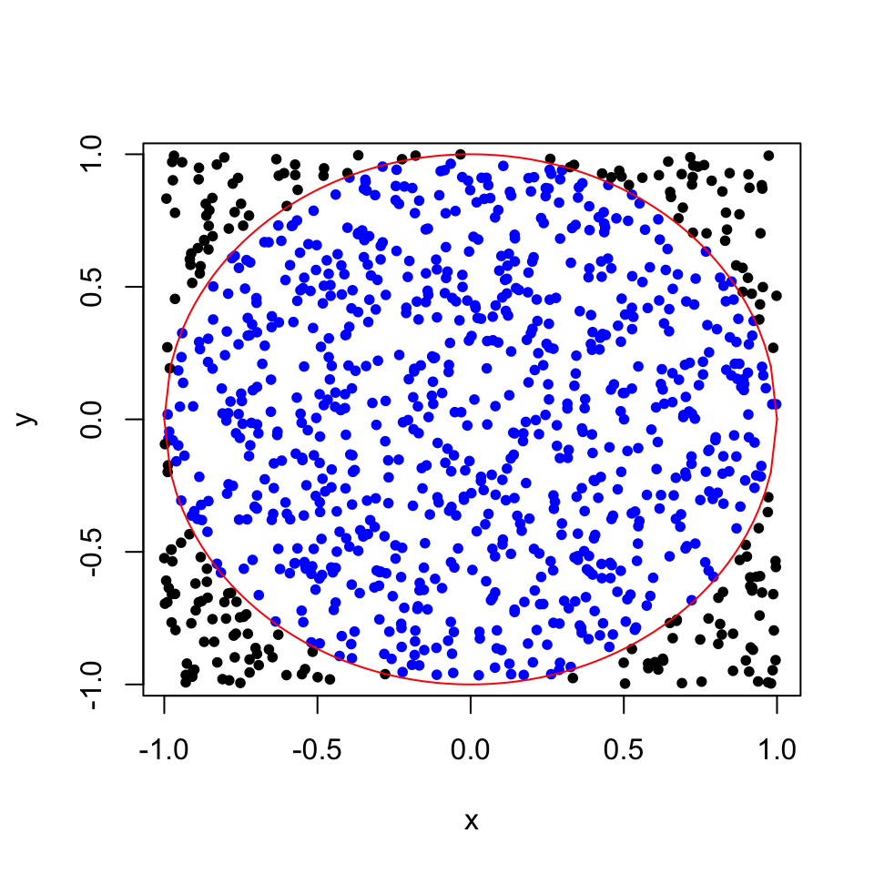

```r
#ou
plot(xCarre[which(xyDisque==1)], yCarre[which(xyDisque == 1)],
     col = "blue",
     pch = 20,
     xlab = "x",
     ylab = "y")
points(xCarre[which(xyDisque==0)], yCarre[which(xyDisque == 0)], col = "black", pch = 20)

curve(sqrt(1 - x^2), add = TRUE, from = -1, to = 1, col = "red")
curve(-sqrt(1 - x^2), add = TRUE, from = -1, to = 1, col = "red")
```

14. Calculer la proportion de points appartenant au disque unité. En déduire une approximation de l’aire du disque unité.

```r
mean(unifCarre$disque)
```

```
## [1] 0.783
```

```r
#ou
mean(xyDisque)
```

```
## [1] 0.785
```

La proportion de points dans le disque $\mathcal{D}$ notée $\hat{p}_{\mathcal{D}}$ correspond à une approximation de la probabilité qu’un point $(x, y)$ soit dans le disque $\mathcal{D}$, *i.e* :

$$\hat{p}_{\mathcal{D}} \simeq \mathbb{P}\left((x, y) \in \mathcal{D} \right)$$

Or, si $\mathcal{A}_{\mathcal{C}}$ est l’air du carré, et $\mathcal{A}_{\mathcal{D}}$ celle du disque $\mathcal{D}$, alors on a aussi que :
$$\mathbb{P}\left((x, y) \in \mathcal{D} \right) = \frac{\mathcal{A}_\mathcal{D}}{\mathcal{A}_\mathcal{C}}$$

Ainsi, on obtient : $\mathcal{A}_\mathcal{D} \simeq \mathcal{A}_C \times \hat{p}_\mathcal{C}$ avec ici, $\mathcal{A}_\mathcal{C} = 2^2 = 4$.

```r
mean(unifCarre$disque) * 4
```

```
## [1] 3.132
```

```r
#ou
mean(xyDisque) * 4
```

```
## [1] 3.14
```

On sait que $\mathcal{A}_{\mathcal{D}} = \pi R^2$. Ici, comme le rayon du disque $R$ vaut $1$, on a $\mathcal{A}_\mathcal{D} = \pi$. Cette approche est donc en fait un moyen de donner une valeur approchée de $\pi$ par la méthode de Monte-Carlo.

### 2.2.2 Aire sous la courbe d’une fonction

Prenons l’exemple de la densité gaussienne centrée réduite :
$$f(x) = \frac{1}{\sqrt{2\pi}} \exp \left[-\frac{x^2}{2} \right]$$
On souhaite calculer $\int_{-2}^1 f(x) \, dx$.

15. Tracer la courbe représentative de la densité et déterminer un majorant sur $[-2, 1]$.

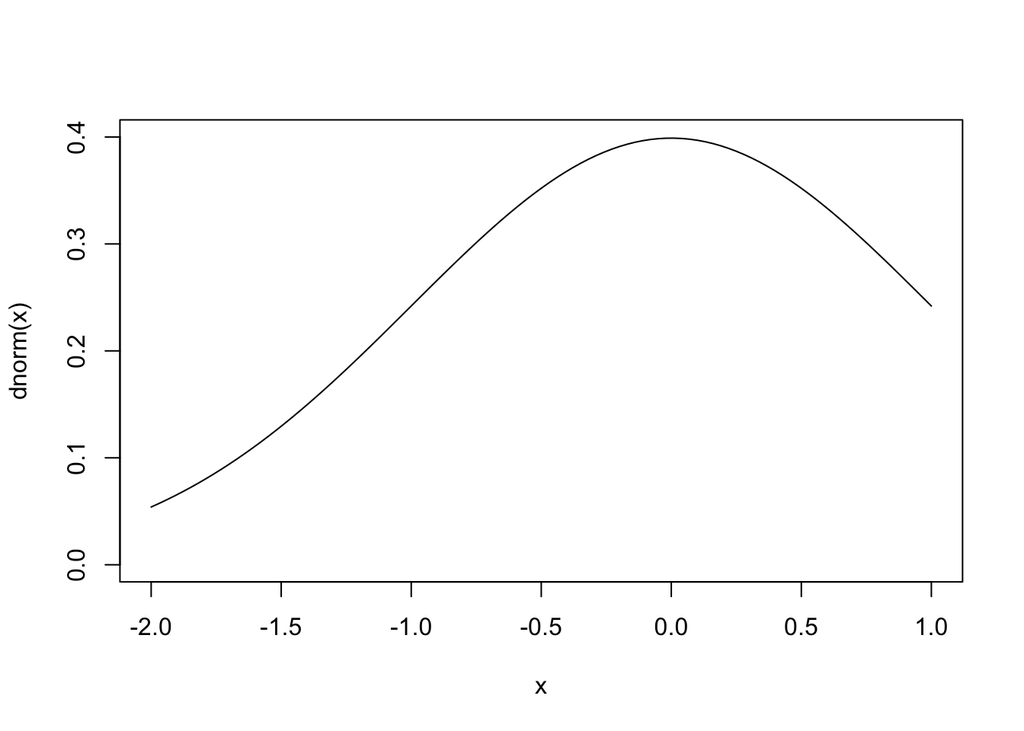

```r
curve(dnorm, from = -2, to = 1, ylim = c(0, 0.4))
```

```r
dnorm(0)
```

```
## [1] 0.3989423
```

16. A l’aide de la méthode de Monte-Carlo, approximer la valeur de l’intégrale recherchée. Vérifier le résultat à l’aide de la fonction `pnorm()`.

L’idée ici est très similaire à celle utilisée pour calculer l’air du disque :

1. On tire $n-$réalisations de variables aléatoires uniformes sur le rectangle $\mathcal{U}([-2,1]) \times \mathcal{U}[0, 0.4])$. On souhaite calculer l’intégrale sur $[-2,1]$, or pour ces valeurs de $x$, $f(x) \in [0,0.4]$, $0.4$ étant le maximum de la densité de la distribution gaussienne centrée-réduite atteint en $x=0$.
2. On regarde ensuite quels points $(x, y)$ se trouvent en dessous de la courbe. Ici, être en dessous de la courbe se traduit par $y \leq f(x)$
3. On calcule la proportion de points se trouvant en dessous de la courbe et on la multiplie par l’air du rectangle pour obtenir une estimation de l’air sous la courbe (donc de l’intégrale) de $f$ entre $-2$ et $1$.

```r
unifRect <- data.frame(x = runif(n, -2, 1), y = runif(n, 0, 0.4))
unifRect <- transform(unifRect, courbe = (y <= dnorm(x)))
mean(unifRect$courbe) * 3 * 0.4
```

```
## [1] 0.8304
```

On connaît la valeur de cette intégrale. En effet :
$$\begin{align*}
\int_{-2}^1f(x)dx &= \int_{-\infty}^1 f(x)dx - \int_{-\infty}^{-2}f(x)dx \\
&= \mathbb{P}(X\leq 1) - \mathbb{P}(X \leq -2) \text{ pour } X \sim \mathcal{N}(0,1)\\
&=\Phi(1) - \Phi(-2) \text{ où } \Phi \text{ désigne la fonction de répartion de la distribution }\mathcal{N}(0,1)
\end{align*}$$

```r
pnorm(1) - pnorm(-2)
```

```
## [1] 0.8185946
```

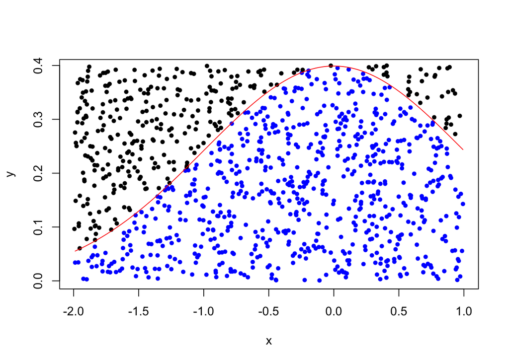

```r
plot(subset(unifRect, courbe, select = c("x", "y")), col = "blue", pch = 20)
points(subset(unifRect, !courbe, select = c("x", "y")), pch = 20)
curve(dnorm, add = TRUE, col = "red")
```

# 3 Méthode du Bootstrap et de Monte-Carlo pour le test de Student

Plaçons nous dans le cadre du test de comparaison de deux moyennes observées. Nous allons étudier *par simulation* les propriétés du test de Student : contrôle de l’erreur de 1ère espèce, calcul de puissance.

17. Commencer par générer deux échantillons de loi normale, chacun de taille $n=15$, de même variance $s^2 = 9$ et de moyennes $10$ et $8$ respectivement pour les groupes $a$ et $b$. Visualiser les données.

```r
n <- 15
a <- rnorm(n, mean = 10, sd = 3)
b <- rnorm(n, mean = 8, sd = 3)
difMoyObs <- mean(a) - mean(b)
difMoyObs
```

```
## [1] 1.556581
```

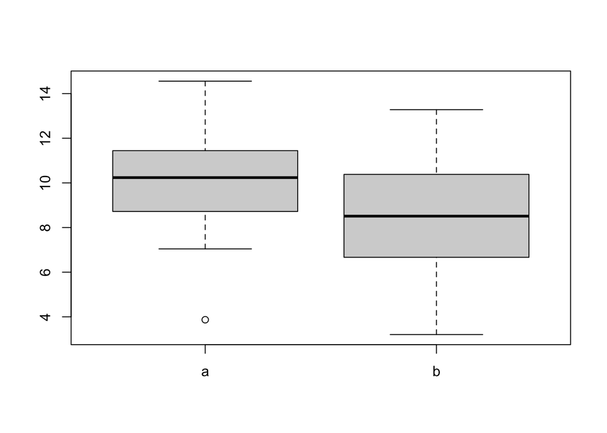

```r
boxplot(data.frame(a, b))
```

18. Sous l’hypothèse d’égalité des variances, effectuer un test de Student unilatéral avec comme hypothèse alternative $H_1 : \mu_a >\mu_b$ au niveau $\alpha=5\%$.  
    [*Utiliser la fonction `t.test()`*]

```r
testStudent <- t.test(x = a, y = b, var.equal = TRUE, alternative = "greater")
testStudent
```

```
##
##  Two Sample t-test
##
## data:  a and b
## t = 1.5977, df = 28, p-value = 0.06067
## alternative hypothesis: true difference in means is greater than 0
## 95 percent confidence interval:
##  -0.1007505        Inf
## sample estimates:
## mean of x mean of y
##  9.895831  8.339250
```

## 3.1 Méthode de Monte-Carlo

19. A l’aide de la méthode de Monte-Carlo, vérifier que le test de Student contrôle bien l’erreur de type I au niveau $\alpha = 5\%$.  
    [*On pourra dans un premier temps fixer le nombre d’échantillons simulés à 1000*]

**Rappel : Erreur de type I**

L’erreur de type I est définie comme étant la probabilité de rejeter $\mathcal{H}_0$ à tord, *i.e* $\mathbb{P}_{\mathcal{H}_0}(\text{rejet } \mathcal{H}_0)$.

Pour estimer cette erreur de type I par la méthode de Monte-Carlo, il faut :

1. Simuler $N$ réalisations des deux échantillons sous $\mathcal{H}_0$, *i.e* avec $\mu_a = \mu_b$
2. Pour chacune des simulations enregistrer la p-valeur renvoyée par le test de Student
3. Finalement, l’erreur de type I du test peut être approchée par la proportion de fois où on a rejeté à tord l’hypothèse nulle dans les $N$ simulations :
   $$\frac{\text{nombre de p-valeurs inférieures à }\alpha}{\text{nombre de simulations}}$$
   *On rejette l’hypothèse nulle au risque $\alpha$ lorsque la p-valeur du test est plus petite que $\alpha$*
4. Le test contrôle l’erreur de type I au niveau $\alpha$ si l’erreur de type I est inférieure ou égale à $\alpha$.

```r
n <- 15
nMC <- 1000
pvaleurs <- rep(NA, nMC)

for (i in 1:nMC) {
  aMC <- rnorm(n, mean = 10, sd = 3)
  bMC <- rnorm(n, mean = 10, sd = 3)
  pvaleurs[i] <- t.test(x = aMC, y = bMC, var.equal = TRUE,
                           alternative = "greater")$p.value
}

estimErrTypeI <- mean(pvaleurs < 0.05)
estimErrTypeI
```

```
## [1] 0.048
```

20. A l’aide de la méthode de Monte-Carlo, calculer la puissance du test de Student pour différentes valeur de $n$. Représenter graphiquement l’évolution de la puissance du test en fonction de la taille de l’échantillon.

**Rappel : Puissance statistique**

La puissance statistique d’un test est définie comme étant la probabilité de rejeter $\mathcal{H}_0$ à raison, *i.e* $\mathbb{P}_{\mathcal{H}_1}(\text{rejet } \mathcal{H}_0)$.

L’estimation de la puissance statistique se fait de la même manière que celle de l’erreur de type I à la seule différence qu’il faut simuler les deux échantillons sous $\mathcal{H}_1$, *i.e* tel que : $\mu_a > \mu_b$

```r
puissance_ttest <- function(n = 15, nMC = 1000, alternative = "greater",
                            alpha = 0.05){
  pvaleurs <- rep(NA, nMC)

  for (i in 1:nMC){
    aMC <- rnorm(n, mean = 10, sd = 3)
    bMC <- rnorm(n, mean = 8, sd = 3)
    pvaleurs[i] <- t.test(x = aMC, y = bMC, var.equal = TRUE,
                           alternative = alternative)$p.value
  }

  return(mean(pvaleurs < alpha))
}

nbObs <- c(5, 10, 20, 30, 50, 100, 200)
estimPuissances <- sapply(nbObs, puissance_ttest, nMC = 1000)
estimPuissances
```

```
## [1] 0.249 0.413 0.651 0.820 0.947 0.999 1.000
```

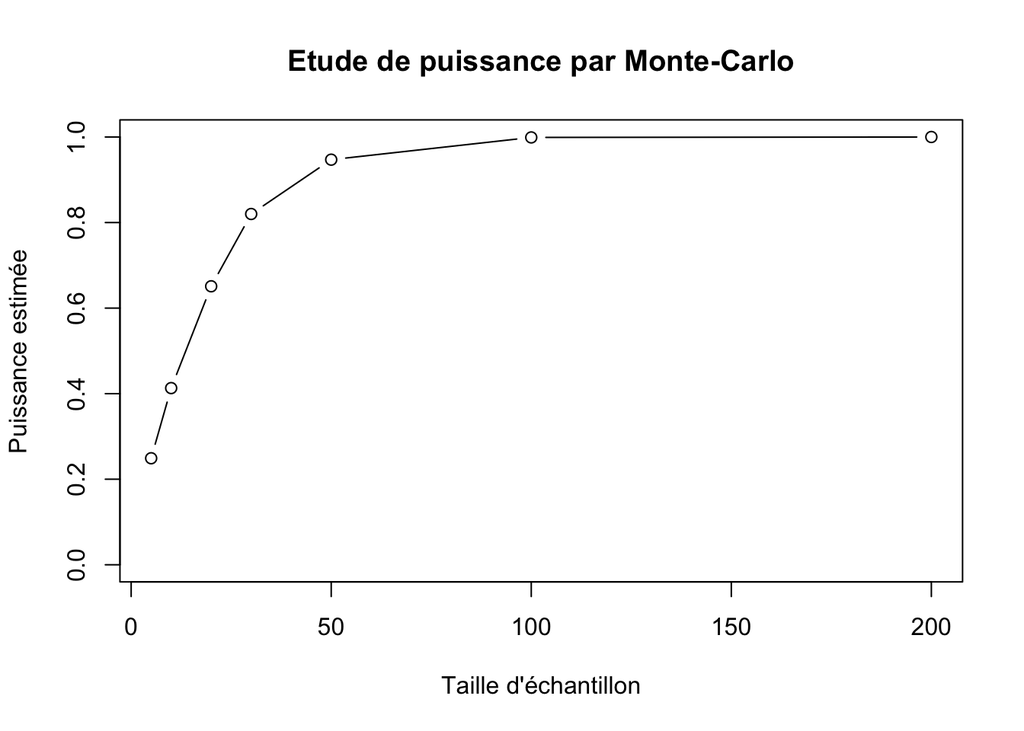

```r
plot(x = nbObs, y = estimPuissances, type = "b", ylim = c(0,1),
     ylab = "Puissance estimée", xlab="Taille d'échantillon",
     main = "Etude de puissance par Monte-Carlo")
```

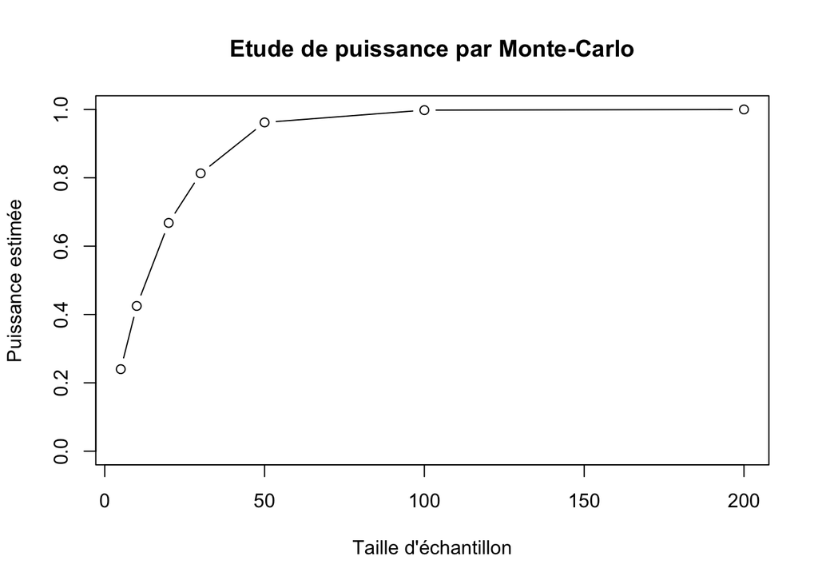

```r
#ou
estimPuissances2 <- rep(NA, length(nbObs))

for (i in 1:length(nbObs)){
  estimPuissances2[i] <- puissance_ttest(n=nbObs[i], nMC=1000)
}

plot(x = nbObs, y = estimPuissances2, type = "b", ylim = c(0,1),
     ylab = "Puissance estimée", xlab="Taille d'échantillon",
     main = "Etude de puissance par Monte-Carlo")
```

## 3.2 Méthode du Bootstrap

**Rappel : Bootstrap**

On suppose que l’on dispose d’un échantillon $\mathcal{L}_n = \{X_1,\dots, X_n\}$ grâce auquel on a estimé un paramètre $\theta$ par $\hat{\theta}$.

Le but du bootstrap est de construire $N$ nouveaux échantillons à partir de $\mathcal{L}_n$ : des échantillons bootstrap, notés $\mathcal{L}^l_n$ pour $l$ allant de $1$ à $N$. Un échantillon bootstrap est obtenu en ré-échantillonnant $\mathcal{L}_n$ : on fait $n$ tirages uniformes avec remise des observations de $\mathcal{L}_n$.

Chaque échantillon bootstrap $\mathcal{L}^l_n$ permet alors d’estimer le paramètre $\theta$ par $\hat{\theta^l}$. On obtient donc $N$ valeurs de $\hat{\theta^l}$.

21. Calculer les différences de moyennes (dans le sens de $H_1$) de $1000$ échantillons bootstrap, puis décrire les valeurs obtenues (valeurs caractéristiques, graphiques).

```r
nboot <- 1000
bootDifMoy <- rep(NA, nboot)

for (i in 1:nboot) {
  a_boot <- a[sample(1:n, size = n, replace = TRUE)]
  b_boot <- b[sample(1:n, size = n, replace = TRUE)]
  bootDifMoy[i] <- mean(a_boot) - mean(b_boot)
}

summary(bootDifMoy)
```

```
##    Min. 1st Qu.  Median    Mean 3rd Qu.    Max.
## -1.5221  0.9087  1.5304  1.5409  2.2120  4.4797
```

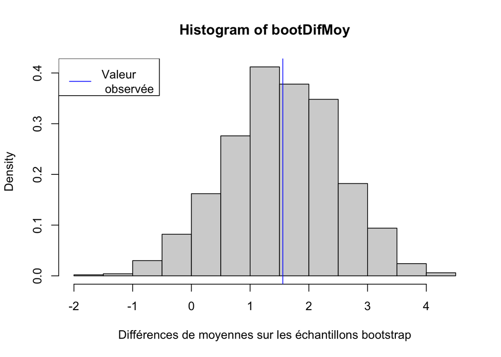

```r
hist(bootDifMoy, probability = TRUE,
xlab = "Différences de moyennes sur les échantillons bootstrap")
abline(v = difMoyObs, col="blue")
legend("topleft", "Valeur \n observée", col="blue", lty = 1)
```

22. En déduire une estimation bootstrap de l’intervalle de confiance au niveau 95% de la différence de moyennes $\mu_a - \mu_b$, et comparer avec la valeur utilisant la loi exacte de la statistique de test renvoyée par la fonction `t.test()`.  
    Comparer également la variance de la différence moyenne estimée par bootstrap avec l’estimateur utilisant la loi exacte de la statistique de test.

```r
quantile(bootDifMoy, 0.05)
```

```
##          5%
## -0.08390962
```

```r
testStudent$conf.int
```

```
## [1] -0.1007505        Inf
## attr(,"conf.level")
## [1] 0.95
```

```r
var(bootDifMoy)
```

```
## [1] 0.9001272
```

```r
(var(a)+ var(b))/n
```

```
## [1] 0.9491685
```

23. Recommencer avec $n=200$ (au lieu de $n=15$) et commenter à nouveau.

```r
n <- 200
a200 <- rnorm(n, mean = 10, sd = 3)
b200 <- rnorm(n, mean = 8, sd = 3)
testStudent200 <- t.test(x = a200, y = b200, var.equal = TRUE,
                        alternative = "greater")
testStudent200
```

```
##
##  Two Sample t-test
##
## data:  a200 and b200
## t = 5.2407, df = 398, p-value = 1.301e-07
## alternative hypothesis: true difference in means is greater than 0
## 95 percent confidence interval:
##  1.100126      Inf
## sample estimates:
## mean of x mean of y
##  9.949757  8.344679
```

```r
nboot <- 1000
bootDifMoy200 <- rep(NA, nboot)

for (i in 1:nboot) {
  a_boot200 <- a200[sample(1:n, size = n, replace = TRUE)]
  b_boot200 <- b200[sample(1:n, size = n, replace = TRUE)]
  bootDifMoy200[i] <- mean(a_boot200) - mean(b_boot200)
}

summary(bootDifMoy200)
```

```
##    Min. 1st Qu.  Median    Mean 3rd Qu.    Max.
##  0.5888  1.4067  1.5931  1.6085  1.8327  2.5067
```

```r
quantile(bootDifMoy200, 0.05)
```

```
##       5%
## 1.088538
```

```r
testStudent200$conf.int
```

```
## [1] 1.100126      Inf
## attr(,"conf.level")
## [1] 0.95
```

```r
var(bootDifMoy200)
```

```
## [1] 0.09938782
```

```r
(var(a200)+ var(b200))/n
```

```
## [1] 0.09380385
```